# Curso PostgreSQL

### Para la tabla `productos`

Comenzamos por ver la estructura de esta tabla

```
SELECT * FROM productos;
```

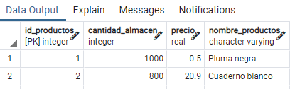

Después generamos los datos en mockaroo, en este caso no serán 1000 inserciones, nos bastarán con generar sólo 100 productos de diferentes marcas

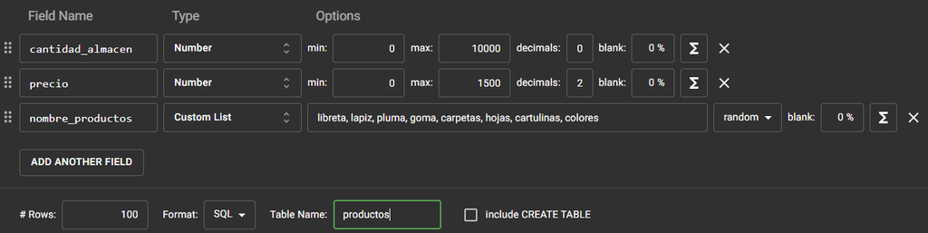

es importante ser cauteloso a la hora de generar los datos. Después abrimos la consola *psql* y realizamos la conexión con *postgres*

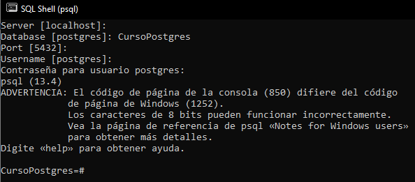

no olvides que en `Database [postgres]:` debes colocar el nombre de la base de datos que almacena la tabla `productos`. Luego, vamos a símbolos del sistema para ejecutar las inserciones

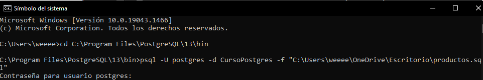

una vez ingresada la contraseña tendremos

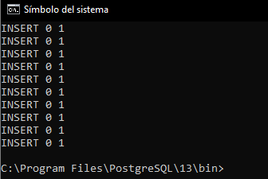

que las inserciones se han ejecutado. Comprobamos yendo a *pgAdmin*, recuerda que antes de realizar la consulta debe refrescar (*refresh*) la tabla o el esquema público

```
SELECT * FROM productos;
```

Primeras 8 filas

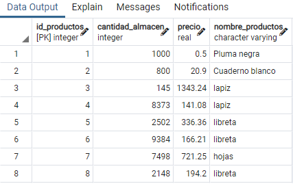

últimas filas

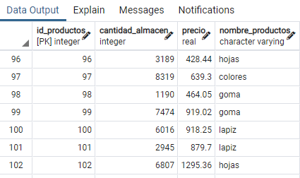

Notamos que la información, en la mayoría de los casos, no tiene sentido, pero el punto es tener datos para trabajar con ellos.

Finalizamos realizando las inserciones de la tabla `ventas`, en ella de igual forma sólo efectuaremos 100 inserciones.

### Para la tabla `ventas`

Comenzamos por

```
SELECT * FROM ventas;
```

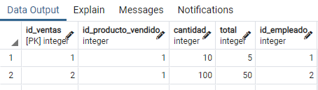

```
-- Eliminamos la columna total
ALTER TABLE ventas DROP COLUMN total;

-- Vemos los cambios
SELECT * FROM ventas;
```

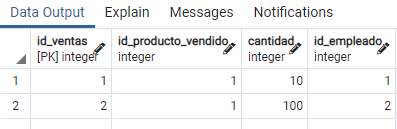

Ahora, tenemos otro problema proveniente de la tabla `empleados`. Si has estado realizando los ejercicios que se dejan en clase, entonces seguramente eliminaste alguna fila de la tabla `empleados`. Aunque se haya eliminado una fila en dicha tabla, el índice generado en automático por el tipo de dato `SERIAL` continúa almacenado en dicha tabla, de tal manera, la fila siguiente a la fila eliminada tendrá como id el número sucesor de la fila eliminada. Por ejemplo, en mi caso

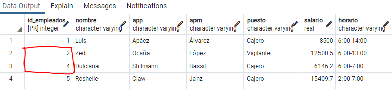

eliminé la fila 3, no obstante, el índice del `id_empleados` excluye de la numeración al número 3. Ahora bien, el problema radica en la columna `id_empleado` de la tabla `ventas` pues, si ingresamos en dicha columna el número 3, entonces *postgres* nos arrojará un error referencial debido a la llave foránea definida en dicha columna. Para resolver el problema

- Ingresamos en mockaroo una fórmula (código) para que se excluya el número 3.

De donde

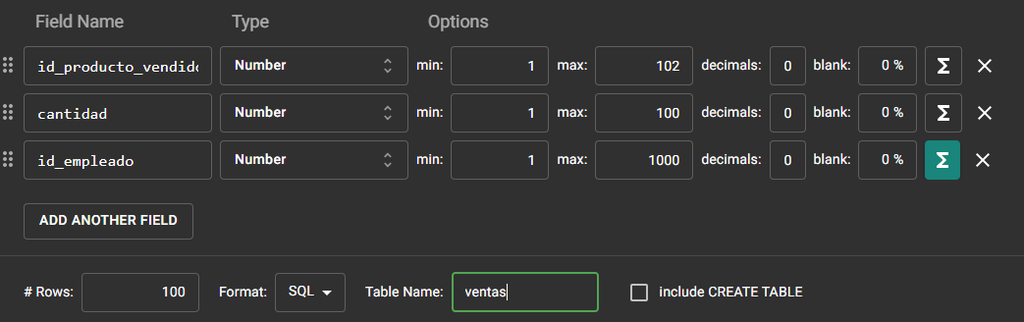

y en la fórmula escribimos

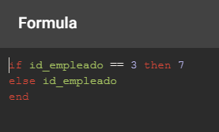

Una vez descargado el archivo vamos a símbolos del sistema para efectuar las inserciones

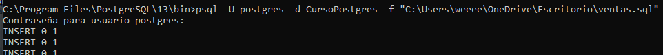

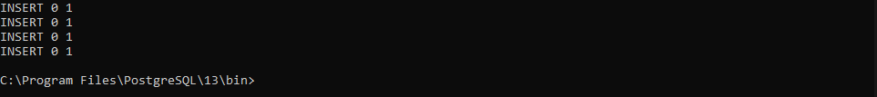

y vemos en *pgAdmin* la actualización de la tabla `ventas`

```
SELECT * FROM ventas;
```

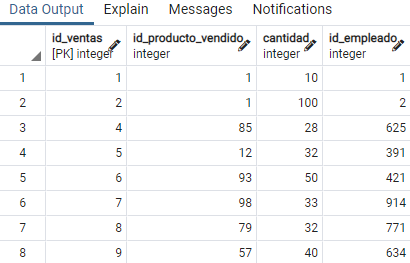

y los últimos registros

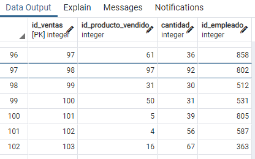

### Generando datos aleatorios utilizando Python (Opcional)

##### Supuestos:

- El alumno tiene conocimientos básicos de Python.

Para realizar lo siguiente, puedes utilizar las libretas de `Python` en [google colab](https://colab.research.google.com/).

Lo que haremos primero será instalar la librería `Faker`, la cual nos permite generar información falsa. Para ello

```python
# Instalamos la libreria
!pip install Faker
```

Cargamos las librerías a utilizar y damos un vistazo a algunas funciones de dicha librería

```python
# Datos falsos
from faker import Faker
# Numeros y selecciones aleatorias
import random
# impresion mas bonita
import pprint

# Configuramos la libreria faker para generar datos en español (Mexico)
fake = Faker(['es_MX'])

# diccionario donde guardaremos toda la info
info = dict()

# Para generar una edad:
# generamos un numero aleatorio entero entre el 18 y 90
edad = random.randint(18, 90)
info['edad']  = edad

# Para el sexo, definimos una lista
sexo = ["M", "F", "O"]

# Con la libreria random podemos hacer una seleccion aleatoria de la lista
# sexo mediante la funcion choice()
sexo1 = random.choice(sexo)
info['sexo']  = sexo1

# Para el sueldo (0,1)
# Con la funcion random() generamos un numero aletorio decimal en el
# intervalo (0,1)
# 0.6879878789 * 10000 = 6879.878789---->6879.87
sueldo = round(random.random() * random.randint(1000, 100000),2)
info['sueldo']  = sueldo

# generamos un nombre aleatorio
nombre = fake.name()
info['nombre']  = nombre

# una direccion
direc = fake.address()
info['dirección']  = direc

# un trabajo
trabajo = fake.job()
info['trabajo']  = trabajo

# una ciudad
ciudad = fake.city()
info['ciudad']  = ciudad

# un curp
curp = fake.curp()
info['curp']  = curp

# Veamos hasta el momento toda la informacion que generamos
pprint.pprint(info)
```

```
{'ciudad': 'San Manuel de la Montaña',
 'curp': 'BUYN570418MVZBCY09',
 'dirección': 'Prolongación República de Moldova 158 Edif. 909 , Depto. 661\n'
              'Nueva Países Bajos, HGO 28192-9641',
 'edad': 28,
 'nombre': 'Bianca Espartaco Badillo Prieto',
 'sexo': 'F',
 'sueldo': 40607.08,
 'trabajo': 'Empleado de biblioteca'}
```

Ahora bien, supongamos que queremos obtener información para la tabla `productos`, de modo que queremos obtener información para las columnas `id_productos, cantidad_almacen, precio, nombre_productos`. Para ello podríamos generar

```python
# simulacion de la info para 5 filas
productos = ["Lapiz", "Goma", "Cartulina", "Colores"]

for id in range(1,6):
    # info
    cantidad_almacen = random.randint(0,100)
    precio = round(random.random() * random.randint(1,1000),2)
    nombre_produtos = random.choice(productos)
    # instruccion
    cadena = f"INSERT INTO productos VALUES ({cantidad_almacen}, {precio}, '{nombre_produtos}');"
    # mostramos
    print(cadena)
```

```
INSERT INTO productos VALUES (41, 626.63, 'Colores');
INSERT INTO productos VALUES (16, 465.09, 'Goma');
INSERT INTO productos VALUES (88, 65.95, 'Cartulina');
INSERT INTO productos VALUES (58, 291.06, 'Colores');
INSERT INTO productos VALUES (11, 199.46, 'Lapiz');
```

Donde, con dichos inserts, ya podríamos ejecutarlos en pgAdmin. Podríamos copiar dichos inserts y después pegarlos en alguna *Query tool* en pgAdmin, no obstante, lo que haremos será crear un archivo que tenga todos los inserts y después lo ejecutaremos utilizando la consola, así como hicimos con los datos generados en Mockaroo. Para ello

```python
# Creamos un archivo txt
inserts = open("DatosPython.txt","w")

# lista de productos
productos = ["Lapiz", "Goma", "Cartulina", "Colores", "Plumas", "Cuadernos"]

# Obtendremos 100 registros
for id in range(1,101):
    # info
    cantidad_almacen = random.randint(0,100)
    precio = round(random.random() * random.randint(1,1000),2)
    nombre_produtos = random.choice(productos)
    # instruccion
    cadena = f"INSERT INTO productos VALUES ({cantidad_almacen}, {precio}, '{nombre_produtos}');"
    # escribiremos la cadena de texto anterior en el archivo txt
    inserts.write(cadena)
    # Salto de linea en el archivo txt
    inserts.write("\n")
# Cerramos el archivo txt
inserts.close()
```

Dicho archivo se descargará en automático, después lo abrimos y lo guardaremos como un archivo .sql

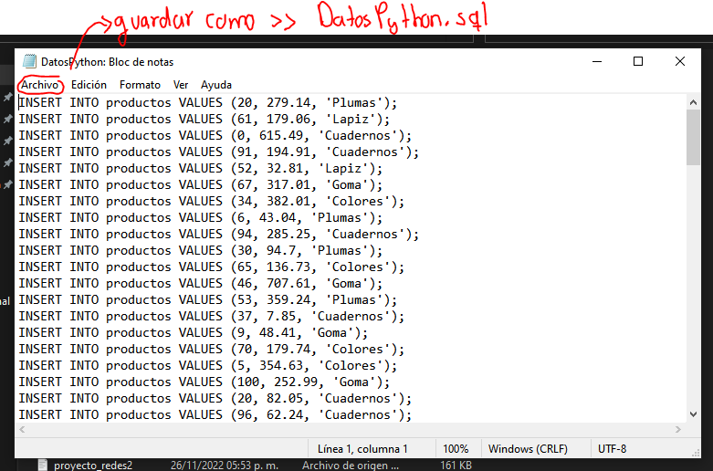

Una vez que ya tenemos dicho archivo (y sabemos la ubicación en la que se encuentra), procedemos a realizar el mismo proceso en consola como lo vimos antes.

Adicionalmente, si queremos otro tipo de información para nuestras tablas, podemos utilizar, como se vio, la librería `Faker`, recordemos que

```python
pprint.pprint(info)
```

```
{'ciudad': 'San Manuel de la Montaña',
 'curp': 'BUYN570418MVZBCY09',
 'dirección': 'Prolongación República de Moldova 158 Edif. 909 , Depto. 661\n'
              'Nueva Países Bajos, HGO 28192-9641',
 'edad': 28,
 'nombre': 'Bianca Espartaco Badillo Prieto',
 'sexo': 'F',
 'sueldo': 40607.08,
 'trabajo': 'Empleado de biblioteca'}
```

por lo que podríamos generar nombres, CURPS, direcciones falsas, entre otros más.

Aquí otro ejemplo (se requieren conocimientos en las librerías SQLite y Pandas) a la hora de generar información falsa [Libreta en google colab](https://colab.research.google.com/drive/1NBUsIHroiCOqdXFWF2F6AnEjTpVKXNdy?usp=sharing)

### Ejercicio

De las tablas adicionales que creaste (es decir aquellas tablas que no son `empleados, productos, ventas`) en la base de datos (referente al proyecto). Crea las inserciones utilizando cualquiera de los dos métodos que vimos en esta clase, es decir, generando los datos en Mockaroo o en Python.